# Лабораторна робота 3. Статистичне висновування

Команда №15

## Огляд

В даній лабораторній роботі буде досліджено експоненціальний розподіл в R і порівняно його з центральною граничною теоремою.

## Симуляції

Як і вказано в завданні, для всіх симуляцій встановлено lambda = 0,2, distributions_num = 40 (кількість розподілів), simulations_num = 1000 (кількість симуляцій). Досліджуватись будуть середні значення експоненціальних розподілів.

```r
lambda = 0.2
distributions_num = 40
simulations_num = 1000
simulation_list <- replicate(simulations_num, mean(rexp(distributions_num, lambda)))
```

## Середнє значення вибірки проти теоретичного середнього значення

Знайдемо середнє значення вибірки та теоретичне середнє значення. Теоретичне значення обчислюється за формулою 1/λ.

```r
mean_of_simulations <- mean(simulation_list)
theoretical_mean <- 1/lambda
```

Побудуємо відповідну гістограму для розподілу середніх значень вибірок і виведемо отримані середнє значення вибірки та теоретичне середнє значення вибірки. Бачимо, що значення обох результатів відрізняються незначно.

```r
hist(simulation_list, col='white')
abline(v = c(theoretical_mean, mean_of_simulations), col = c('red', 'green'), lwd = 2, lty = 'dashed')
```

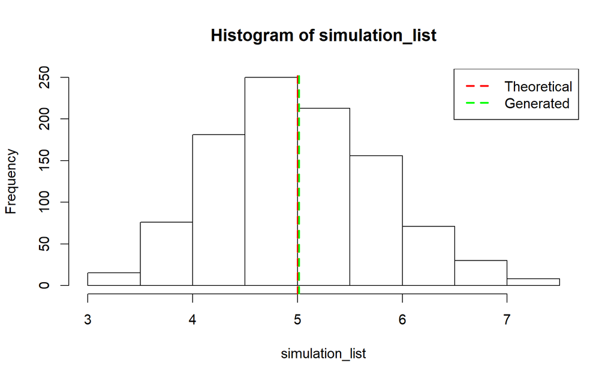

```r
legend("topright", c('Theoretical', 'Generated'), col = c('red', 'green'), lwd = 2, lty = 'dashed')
```

```r
paste("Mean of sim", mean_of_simulations)
```

```
[1] "Mean of sim 5.01453718295491"
```

```r
paste("Theor mean", theoretical_mean)
```

```
[1] "Theor mean 5"
```

## Дисперсія вибірки проти теоретичної дисперсії

Знайдемо дисперсію вибірки та теоретичну дисперсію. Теоретична дисперсія в нашому випадку обчислюється за формулою (1/λ)^2 / 40.

```r
variance_of_simulations <- var(simulation_list)
theoretical_variance <- (1/(lambda)^2)/distributions_num
```

Виведемо отримані значення. Бачимо, що значення обох результатів відрізняються незначно.

```r
paste("var of sim", variance_of_simulations)
```

```
[1] "var of sim 0.601786037496081"
```

```r
paste("Theor var", theoretical_variance)
```

```
[1] "Theor var 0.625"
```

## Розподіл

Щоб довести, що розподіл є нормальним, побудуємо і дослідимо гістограму. Отримана гістограма має дзвіноподібну форму Також нанесемо лінію щільності нормального розпоідлу за допомогою функції lines. Щільність масштабується таким чином, щоб вона відповідала побудованій гістограмі. Отриманий результат приблизно відповідає нормальному розподілу.

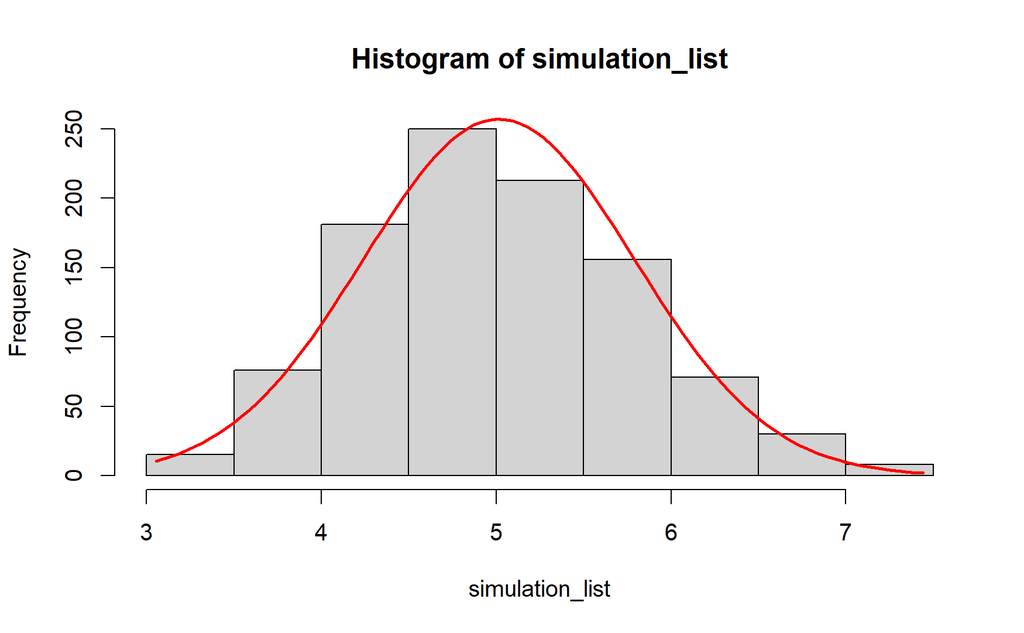

```r
hist_data <- hist(simulation_list)
max_hist <- max(hist_data$counts)

x_values <- seq(min(simulation_list), max(simulation_list), length.out = 100)
lines(x_values, dnorm(x_values, mean = mean_of_simulations, sd = sqrt(variance_of_simulations)) * sum(hist_data$counts) * diff(hist_data$breaks[1:2]), col = 'red', lwd = 2)
```

Також можемо скористатись методом побудови Q-Q графіку. Червоним кольором нанесено очікувані значення нормального розподілу, а чорним - отримані нами значення. Бачимо, що розподіл є приблизно нормальним.

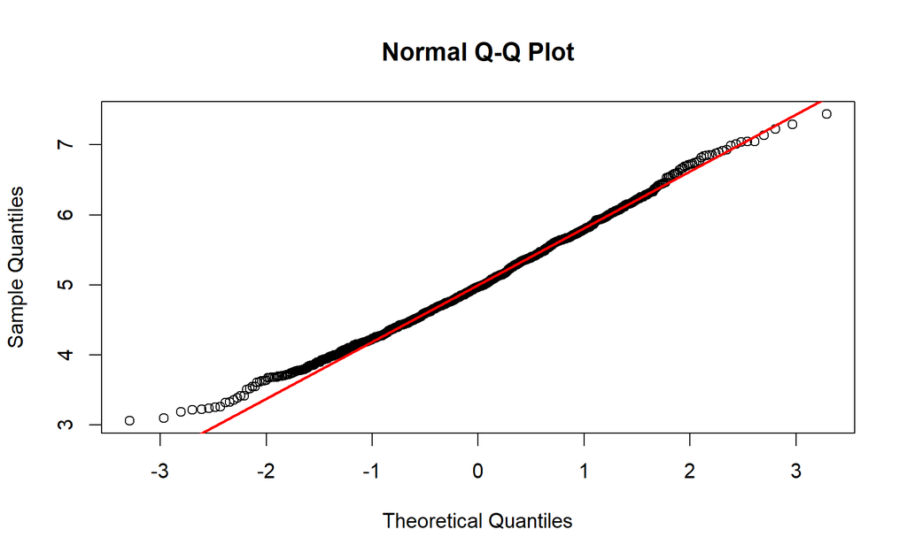

```r
qqnorm(simulation_list)
qqline(simulation_list, col="red", lwd = 2)
```